# Chunchbase Startup Funding Data

##### By: Joshua Meek

## Introduction

The current start-up funding lifecycle typically consists of various rounds of funding from angel investors, family offices, venture capitalists, and more. Having insight into the current state of start-up investments can give other founders the opportunity to form business plans and other aspects of their own start-up. Crunchbase is a web platform dedicated to providing this type of insight into every start-up’s funding and latest news. Luckily, Crunchbase provides the opportunity to download this data for developers and this report will be using Crunchbase data from the year 2015. First, I will show you how to curate, clean, and parse the data into something that is more manageable. Second, I will process the data and perform exploratory data analysis (along with visualizations) to develop a hypothesis. Finally, I will test the developed hypothesis by applying some machine learning to the dataset.

## Required Language and Libraries

To perform this analysis one will need the latest version of R along with the following libraries:

- broom
- caret
- ggplot2
- purrr
- randomForest
- ROCR
- tidyverse

The latest version of R can be download from https://www.r-project.org/

The following code block imports all of the required libraries for this report:

```r
library(broom)
library(caret)
library(ggplot2)
library(purrr)
library(randomForest)
library(ROCR)
library(tidyverse)
```

## Data Curation

First, download the Crunchbase 2015 dataset from https://github.com/notpeter/crunchbase-data. The ZIP download will come with a series of CSV (comma-separated values) files however the only file we care about for this report is the `rounds.csv` file. We will use the standard libaray in R to read our file into our environment so we can begin the data curation step of the process.

**Note:** You will need to make sure that R is reading the file from the working directory or in a path that points to subdirectory (branching from the working directory). For more information visit http://rfunction.com/archives/1001

```r
# Load the data
rounds_data <- read.csv('rounds.csv')

# Show only the first row
rounds_data %>% head(2)
```

```
##        company_permalink company_name
## 1    /organization/-fame        #fame
## 2 /organization/-qounter     :Qounter
##                                  company_category_list
## 1                                                Media
## 2 Application Platforms|Real Time|Social Network Media
##   company_country_code company_state_code company_region  company_city
## 1                  IND                 16         Mumbai        Mumbai
## 2                  USA                 DE     DE - Other Delaware City
##                           funding_round_permalink funding_round_type
## 1 /funding-round/9a01d05418af9f794eebff7ace91f638            venture
## 2 /funding-round/22dacff496eb7acb2b901dec1dfe5633            venture
##   funding_round_code  funded_at raised_amount_usd
## 1                  B 2015-01-05             1e+07
## 2                  A 2014-10-14                NA
```

### A Peek at the Data

Although the output is not pleasant to look at (yet), we can now see some of the features that are present in our dataset. For a given funding round of a company we have: company_permalink, company_name, company_category_list, company_country_code, company_state_code, company_region, company_city, funding_round_permalink, funding_round_type, funding_round_code, funding_at, and raised_amount_usd.

### Tidying the Data

To perform any analysis on our dataset we first want to make sure that the columns in the dataframe are of their appropriate types. We can use the `sapply` function to check the types of each column in our dataset.

```r
# Output column types
sapply(rounds_data, class)
```

```
##       company_permalink            company_name   company_category_list
##                "factor"                "factor"                "factor"
##    company_country_code      company_state_code          company_region
##                "factor"                "factor"                "factor"
##            company_city funding_round_permalink      funding_round_type
##                "factor"                "factor"                "factor"
##      funding_round_code               funded_at       raised_amount_usd
##                "factor"                "factor"               "numeric"
```

As shown above, by looking at the class of each column in the dataframe, every column is of type `factor` except the `raised_amount_usd` column which is of type `numeric`. By looking both at the names of each column and the two row subset that was shown earlier, all columns need to be of character type except the ones named `funded_at` and `raised_amount_usd`. In addition to that, the column `company_category_list` appears to have multiple values stores in one column, delimited by the `|` character, that need to be split out into separate columns.

To convert the column types from factor to character we will apply the `as.character` function over the columns we wish to mutate. However, was cannot apply this function over every column in the dataframe because there are a couple columns we want to be different types. We can pass in the negation of these columns in order to avoid their conversion. The following code block shows the mutation of the column types and then the updated list of types for each column.

```r
# Change column types to character except funded_at and raised_amount_usd
rounds_data <- rounds_data %>%
  mutate_at(vars(-funded_at, -raised_amount_usd), as.character)

# Output column types
sapply(rounds_data, class)
```

```
##       company_permalink            company_name   company_category_list
##             "character"             "character"             "character"
##    company_country_code      company_state_code          company_region
##             "character"             "character"             "character"
##            company_city funding_round_permalink      funding_round_type
##             "character"             "character"             "character"
##      funding_round_code               funded_at       raised_amount_usd
##             "character"                "factor"               "numeric"
```

Now we want to change the `funded_at` column to represent the datetime type in order for us to be able to perform exploratory data analysis. First let’s look at the format of this column so we can convert it using the proper datetime format.

```r
# Show the first five values
rounds_data %>%
  select(company_name, funded_at) %>%
  slice(1:5)
```

```
## # A tibble: 5 x 2
##   company_name           funded_at
##   <chr>                  <fct>
## 1 #fame                  2015-01-05
## 2 :Qounter               2014-10-14
## 3 :Qounter               2014-03-01
## 4 (THE) ONE of THEM,Inc. 2014-01-30
## 5 0-6.com                2008-03-19
```

As shown above, by selecting the `funded_at` column and using the slice command to grab the first five columns, we can see that the datetime data is in the format of `%Y-%m-%d`. For more information on datetime formats visit the link here. Now we need to use this format string to convert our factor column into that of a datetime. First we will need to convert the `funded_at` column to character since this operation cannot be performed on a factor (which is the current type). Then we will use the type_convert function with the datetime string `%Y-%m-%d` to parse the column into the correct datetime format.

```r
# Convert the funded_at column to datetime
rounds_data <- rounds_data %>%
  mutate(funded_at = as.character(funded_at)) %>%
  type_convert(cols(funded_at=col_datetime("%Y-%m-%d")))

# Show the first five values
rounds_data %>%
  select(company_name, funded_at) %>%
  slice(1:5)
```

```
## # A tibble: 5 x 2
##   company_name           funded_at
##   <chr>                  <dttm>
## 1 #fame                  2015-01-05 00:00:00
## 2 :Qounter               2014-10-14 00:00:00
## 3 :Qounter               2014-03-01 00:00:00
## 4 (THE) ONE of THEM,Inc. 2014-01-30 00:00:00
## 5 0-6.com                2008-03-19 00:00:00
```

The last tidying change we want to make to our dataframe is to separate out the `company_category_list` column into the individual categories that it contains. It is evident that Crunchbase labels any given company with various categories that it could fall into.

```r
# Show the first five values
rounds_data %>%
  select(company_name, company_category_list) %>%
  slice(1:5)
```

```
## # A tibble: 5 x 2
##   company_name           company_category_list
##   <chr>                  <chr>
## 1 #fame                  Media
## 2 :Qounter               Application Platforms|Real Time|Social Network M…
## 3 :Qounter               Application Platforms|Real Time|Social Network M…
## 4 (THE) ONE of THEM,Inc. Apps|Games|Mobile
## 5 0-6.com                Curated Web
```

The output above shows the first five values for the `company_category_list` column in the dataframe. We can see that the `|` character is the delimeter for the various categories that Crunchbase may label for any given company. There are, however, two challenges that come with this splitting this column. First, different companies have different amount of categories. Second, we need to allow for up to three categories that Crunchbase uses for a company. To do this we will use the separate function. It will use the `|` delimiter to split up the column however we will need to use the regular expression representation `\\|` to match this character. We will also want to use a right fill in order to handle companies which do not have three categories. Finally, we will name these new columns `Category_1`, `Category_2`, `Category_3`.

```r
# Separate Categories into three columns
rounds_data <- rounds_data %>%
  separate(col=company_category_list, sep='\\|', fill='right', into=c('Category_1', 'Category_2', 'Category_3'))

# Show the first five values
rounds_data %>%
  select(company_name, Category_1, Category_2, Category_3) %>%
  slice(1:5)
```

```
## # A tibble: 5 x 4
##   company_name           Category_1            Category_2 Category_3
##   <chr>                  <chr>                 <chr>      <chr>
## 1 #fame                  Media                 <NA>       <NA>
## 2 :Qounter               Application Platforms Real Time  Social Network …
## 3 :Qounter               Application Platforms Real Time  Social Network …
## 4 (THE) ONE of THEM,Inc. Apps                  Games      Mobile
## 5 0-6.com                Curated Web           <NA>       <NA>
```

Now we have three new columns in our dataset used to represent the various column categories that a company can take as categorized by Crunchbase. These can be used in any further analysis if we choose to look at categories.

## Exploratory Data Analysis

In this step of the report, we will perform some exploratory data analysis in order to help us formulate a hypothesis that we can test. We will perform both visual as well as statistical analysis on the Crunchbase dataset.

### Amount Raised Over the Years

Let’s first loook at the amount raised in each round, that we have data for, over the lifecycle of the dataset. We need to make a scatterplot and scale the y axis to make the units US dollars. Look at the plot below, it is hard to really see if the amount raised is increasing or just that more start-ups are being funded in recent years. There are definitely some outliers in this data, with one start-up raising over $20 billion in one round.

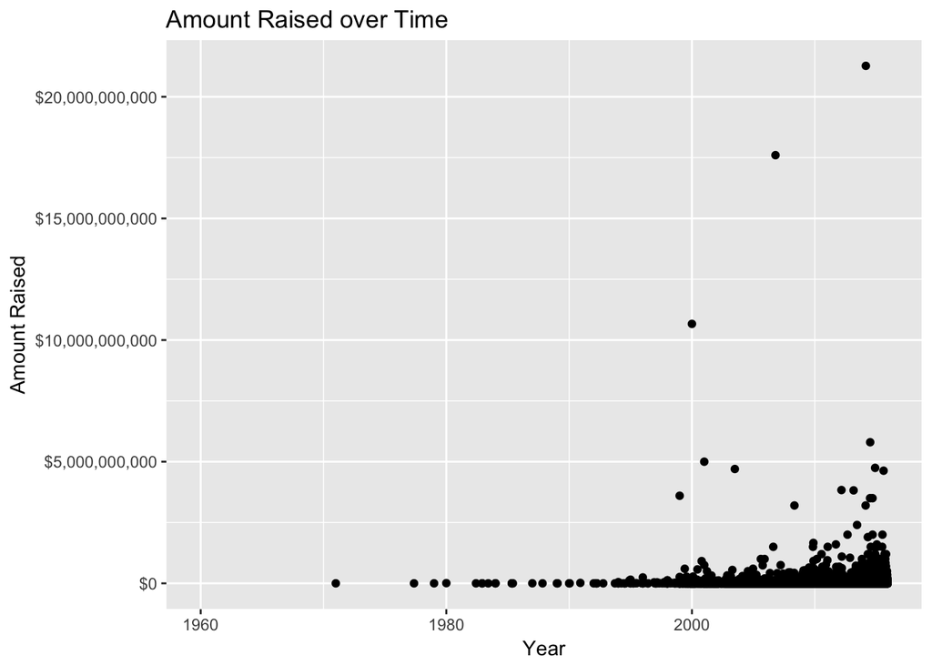

```r
rounds_data %>%
  ggplot(aes(x=funded_at, y=raised_amount_usd)) + geom_point() + scale_y_continuous(labels = scales::dollar) +
  ylab('Amount Raised') + xlab('Year') + ggtitle('Amount Raised over Time')
```

Looking at the summary statistics for the `raised_amount_usd` and removing those entries which were missing, we can see that the outliers play a large role in the statistics. With a mean of 10430000, median of 1681000, and standard deviation of 114821248 we can see a large skew in the data. This may not be beneficial for developing our hypothesis but in order to be sure we should also look at the yearly break down for funding.

```r
# Disable scientific notation
options(scipen=999)

# Get summary of amount raised
summary(na.omit(rounds_data$raised_amount_usd))
```

```
##        Min.     1st Qu.      Median        Mean     3rd Qu.        Max.
##           0      322500     1681000    10430000     7000000 21270000000
```

```r
# Get standard deviation
sd(na.omit(rounds_data$raised_amount_usd))
```

```
## [1] 114821248
```

### Total Amount Of Rounds per Year

Looking at the total amount of funding rounds per year from the Crunchbase dataset, it is evident that there are more start-ups funded in the recent years. It is very heavily skewed towards the recent years. This is great for start-ups looking for funding but not so great for our analysis. Skew takes away from the central tendency of the data. In making our plot we want to make a new column in the dataframe where we strip out the year only from the `funded_at` column.

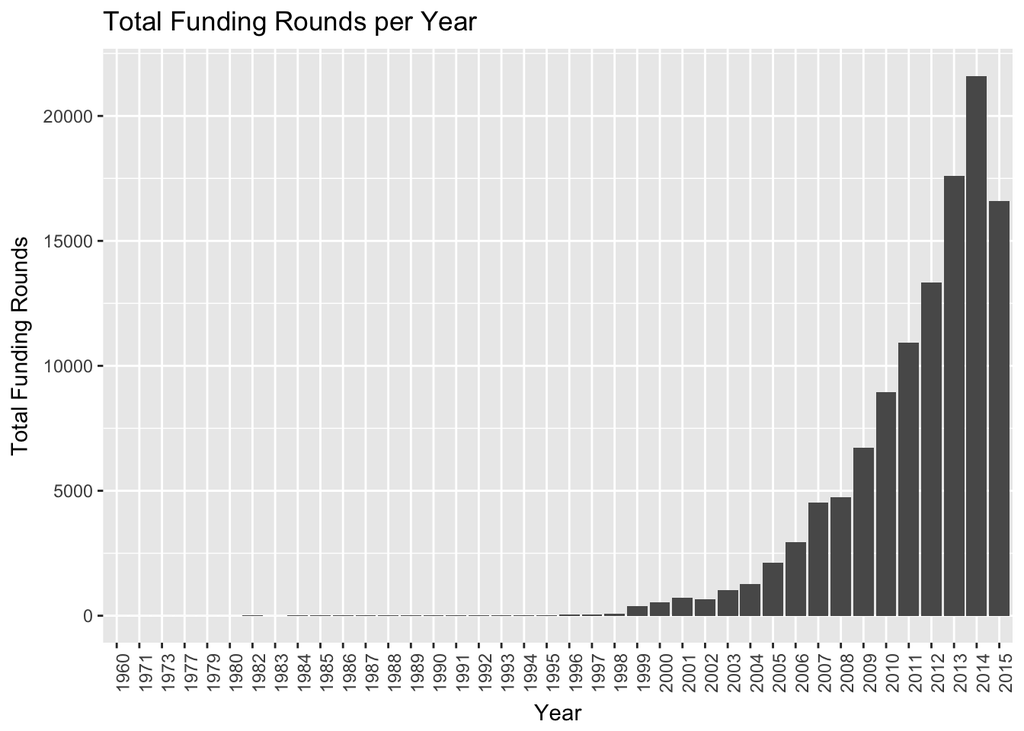

```r
rounds_data %>%
  mutate(year = format(funded_at, format='%Y')) %>%
  ggplot(aes(x=year)) + geom_bar() +
  ylab('Total Funding Rounds') + xlab('Year') + ggtitle('Total Funding Rounds per Year') +
  theme(axis.text.x = element_text(angle = 90, hjust = 1))
```

### Average Amount Raised per Year

Looking at the average amount raised per year tells a different story than we saw above. While the amount of total funding rounds seems to be increasing, the average amount raised seems to be decreasing after the year 2000 (maybe due to the Dot Com Bubble). This provides some interesting insight into our data that was not previously evident. We can see that the largest average, possibly due to the large outliers, lies near the year 2000 which could again be contributed to the Dot Com Bubble. To make this plot we need to again make a year column however we also need to group by those years so we can have one point on the x-axis for each year. We also need to make a new column which is the mean_raised showing the average amount raised grouped by year.

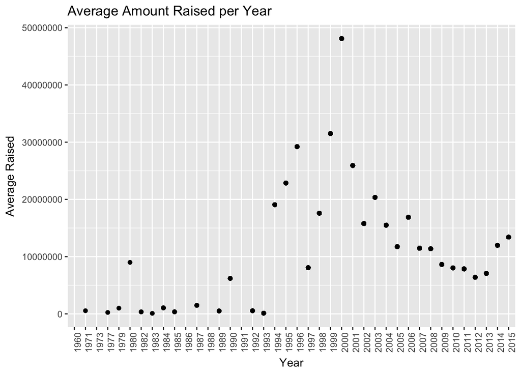

```r
rounds_data %>%
  mutate(year = format(funded_at, format='%Y')) %>%
  group_by(year) %>%
  mutate(mean_raised = mean(na.omit(raised_amount_usd))) %>%
  ggplot(aes(x=year, y=mean_raised)) + geom_point() +
  ylab('Average Raised') + xlab('Year') + ggtitle('Average Amount Raised per Year') +
  theme(axis.text.x = element_text(angle = 90, hjust = 1))
```

Let’s look at the breakdown of the average amount raised per year. Now we can see that our large outlier does in fact lie with the year 2000, right before the burst of the Dot Com Bubble. By using the same logic we used to generate the dataset for our plot above, we can make a smaller table that shows each year and the average amount raised for that year. We also want to look at the standard deviations for the amount funded. By looking at that we can see some incredible large standard deviations and also those years where there was no deviation at all.

```r
rounds_data %>%
  mutate(year = format(funded_at, format='%Y')) %>%
  group_by(year) %>%
  mutate(mean_raised = mean(na.omit(raised_amount_usd))) %>%
  mutate(sd_raised = sd(na.omit(raised_amount_usd))) %>%
  distinct(year, mean_raised, sd_raised) %>%
  arrange(desc(year)) %>%
  print(n=40)
```

```
## # A tibble: 40 x 3
## # Groups:   year [40]
##    year  mean_raised  sd_raised
##    <chr>       <dbl>      <dbl>
##  1 2015    13419043.  71535027.
##  2 2014    11976357. 183412179.
##  3 2013     7063927.  47207300.
##  4 2012     6395021.  47488992.
##  5 2011     7856431.  34451773.
##  6 2010     8039308.  33333408.
##  7 2009     8639238.  42374463.
##  8 2008    11384305.  56343086.
##  9 2007    11480601.  25380116.
## 10 2006    16880335. 346729696.
## 11 2005    11739759.  40200966.
```

[output cut: 29 more lines]

### Round Types and Codes

Let’s shift our focus away from direct numbers in funding amounts and instead start to look at the types of funding rounds that are happening.

First let’s look at the `funding_round_type` column. As shown in the plot below there is a large focus of funding coming from *seed* and *venture* rounds. This is great news for our analysis because *venture* funding generally takes on ‘Series’ codes such as A, B, C, or D. You can read more about venture funding [here](https://en.wikipedia.org/wiki/Venture_round). This is starting to lead us down the route of a hypothesis to test.

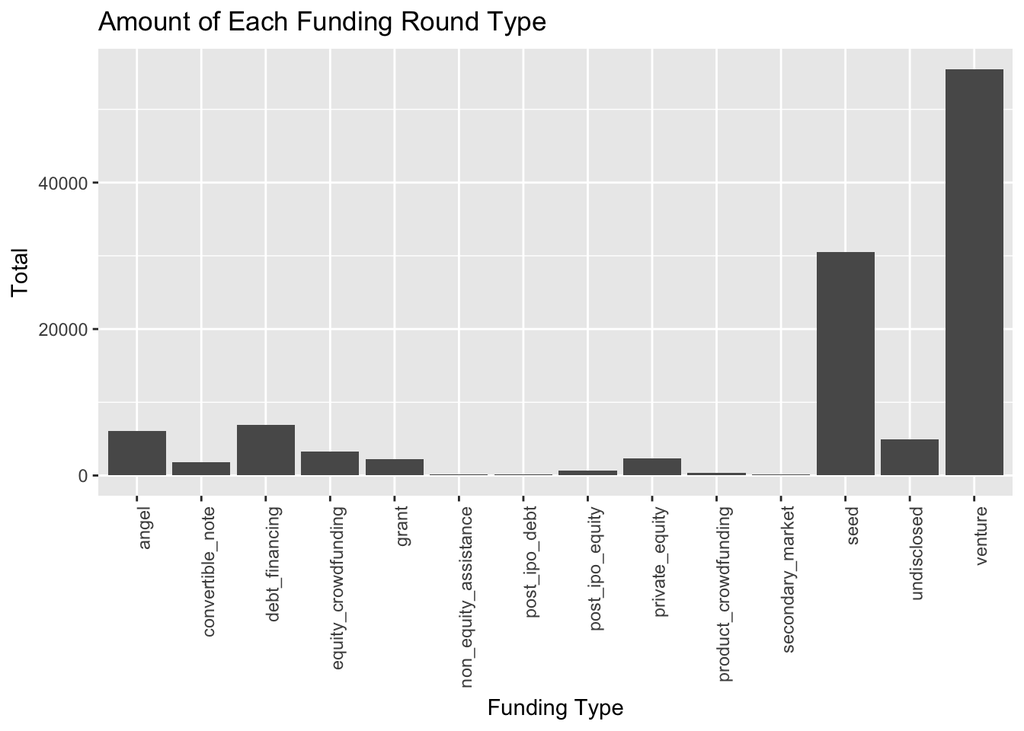

```r
rounds_data %>%
  ggplot(aes(x=funding_round_type)) + geom_bar() +
  ylab('Total') + xlab('Funding Type') + ggtitle('Amount of Each Funding Round Type') +
  theme(axis.text.x = element_text(angle = 90, hjust = 1))
```

Taking a table breakdown of the counts, we can again see that the seed and venture round types dominate the dataset.

```r
rounds_data %>%
  group_by(funding_round_type) %>%
  count(funding_round_type)
```

```
## # A tibble: 14 x 2
## # Groups:   funding_round_type [14]
##    funding_round_type        n
##    <chr>                 <int>
##  1 angel                  6094
##  2 convertible_note       1817
##  3 debt_financing         6895
##  4 equity_crowdfunding    3257
##  5 grant                  2200
##  6 non_equity_assistance   191
##  7 post_ipo_debt           152
##  8 post_ipo_equity         638
##  9 private_equity         2285
## 10 product_crowdfunding    410
## 11 secondary_market         95
## 12 seed                  30524
## 13 undisclosed            4897
## 14 venture               55494
```

It is common practice for venture rounds to take on a series code so let’s look at a plot of the counts for the series codes. Upon first look it is very evident that there are a large number of NA’s in the dataset for `funding_round_code`. Do not let this alarm you, this is due to the other types of funding that does not carry a series code with it. (such as seed, grant, angel, etc…) What is interesting, however, is how the amount of each series code seems to taper off as we move higher up the alphabet. This is interesting because it leads us to believe that less and less startups either need or reach later rounds of funding. Now we have a baseline for generating our hypothesis.

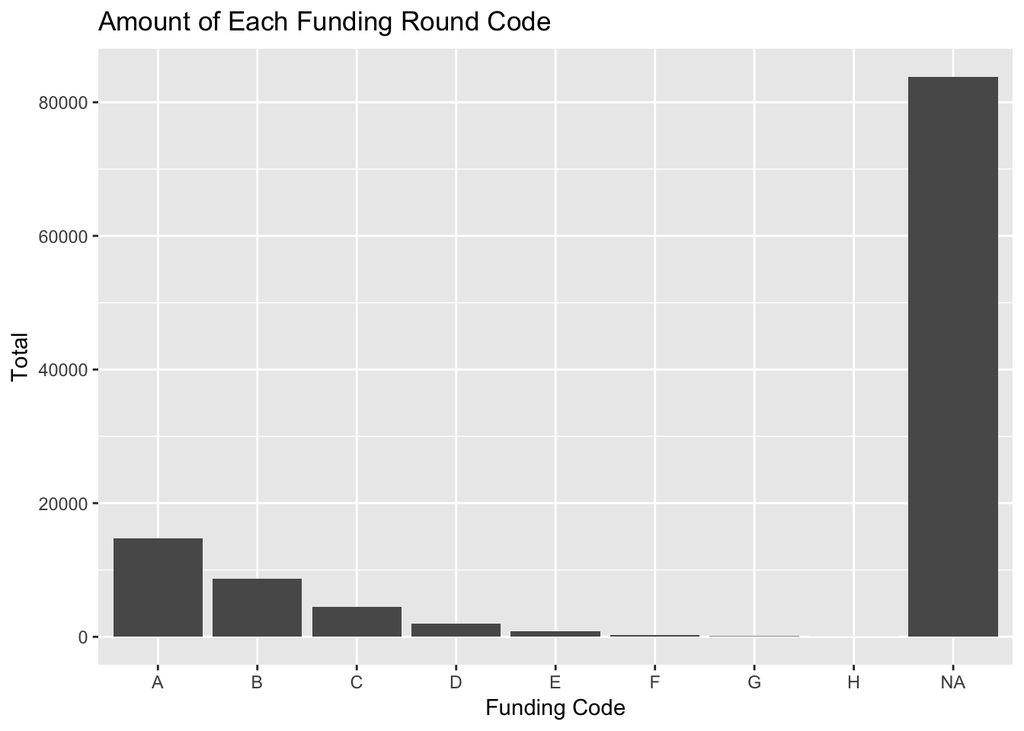

```r
rounds_data %>%
  ggplot(aes(x=funding_round_code)) + geom_bar() +
  ylab('Total') + xlab('Funding Code') + ggtitle('Amount of Each Funding Round Code')
```

A brief look at the counts for each series code will again show us the decrease in counts with each later series. It will also show us the large amount of rounds which do not have series codes.

```r
rounds_data %>%
  group_by(funding_round_code) %>%
  count(funding_round_code)
```

```
## # A tibble: 9 x 2
## # Groups:   funding_round_code [9]
##   funding_round_code     n
##   <chr>              <int>
## 1 A                  14747
## 2 B                   8713
## 3 C                   4476
## 4 D                   2025
## 5 E                    811
## 6 F                    283
## 7 G                     73
## 8 H                     12
## 9 <NA>               83809
```

## Machine Learning

In this section of the report we will use supervised machine learning to predict an outcome. We will take our training dataset and determine how well our predictor predicts the test data set.

### Hypothesis

> Does the amount raised in a Series A have an effect on having a Series B funding round?

### Preparing Data

In order to start performing the predictions on our data we need to “trim the fat” on the dataframe. So we are going to remove all rows that do not have `funding_round_code` and only keep the columns we will need for our analysis (`company_name`, `funding_round_code`, `funded_at`, `raised_amount_usd`). Now we can see below that we have this dataframe in place with the appropriate columns.

```r
# Keep those with a funding round code and select the columns we want
coded_rounds_data <- rounds_data %>%
  filter(!is.na(funding_round_code)) %>%
  select(company_name, funding_round_code, funded_at, raised_amount_usd)

# Show head
coded_rounds_data %>%
  head()
```

```
##             company_name funding_round_code  funded_at raised_amount_usd
## 1                  #fame                  B 2015-01-05          10000000
## 2               :Qounter                  A 2014-10-14                NA
## 3 (THE) ONE of THEM,Inc.                  B 2014-01-30           3406878
## 4                0-6.com                  A 2008-03-19           2000000
## 5                 H2O.ai                  B 2015-11-09          20000000
## 6                 H2O.ai                  A 2014-07-19           8900000
```

Now we are going to want to make a predictor dataframe with each unique company, the amount raised in Series A, and whether or not that company raised a Series B. To do this, we first group by the company name. Then we append either *yes* or *no* to a new column called `series_b` if any of the company’s funding rounds include the code *B*. This column also needs to be of type factor with the levels set as either *yes* or *no* corresponding to their respective values. Then we filter it to take only the series A funding rounds and remove all rows which do not have a publicly disclosed amount of funding for their Series A. In the end we have a new dataframe with the company name, the amount raised in the Series A, and whether or not the company raised a Series B.

```r
# Generate predictor dataframe
predictor_df <- coded_rounds_data %>%
  group_by(company_name) %>%
  mutate(series_b = ifelse(any(funding_round_code == 'B'), 'yes', 'no')) %>%
  filter(funding_round_code == 'A') %>%
  filter(!is.na(raised_amount_usd)) %>%
  mutate(series_b = factor(series_b, levels=c('yes', 'no'))) %>%
  select(company_name, series_a_funding=raised_amount_usd, series_b)

# Show head
predictor_df %>%
  head()
```

```
## # A tibble: 6 x 3
## # Groups:   company_name [5]
##   company_name    series_a_funding series_b
##   <chr>                      <dbl> <fct>
## 1 0-6.com                  2000000 no
## 2 H2O.ai                   8900000 yes
## 3 10 Minutes With          4000000 no
## 4 1000memories             2520000 no
## 5 ZenChef                  1736910 yes
## 6 ZenChef                  1800000 yes
```

### Training A Classifier

We need to split up our data into training and testing regions. First, we set the seed of our project to be `0320` to ensure consistent results between runs and if someone were to recreate this experiment. (Read more about seeds in R [here](http://rfunction.com/archives/62)) Now we will be using a random 80/20 split for our data. For our test dataframe we use a random fraction of 20% of the data to generate that dataframe. Then the training dataframe is just the antijoin of the remaining 80% of the data.

You may wonder why we do this and the answer is simple. We use the training data to run a classification on which essentially attempts to learn a model on how to classify if a company will have a Series B based on the funding from their Series A. Then we take that model and attempt to predict outcome in the testing data (whether a Series B was raised or not) and evaluate the results.

```r
# Set seed
set.seed(0320)

# Make testing dataframe
test_df <- predictor_df %>%
  group_by(series_b) %>%
  sample_frac(.2) %>%
  ungroup()

# Make training dataframe
train_df <- predictor_df %>%
  anti_join(test_df, by='company_name')
```

Now that we have our testing and training data separate from one another we can fit a model and use it for some predictions. In this example we will be using the Random Forest learning method for classification (learn more about random forest [here](https://en.wikipedia.org/wiki/Random_forest)). In the code below, we learn the random forest using the default parameters. Essentially, we are trying to teach the classifier to come to a conclusion about `series_b` based on the values found in `series_a_funding`; all using the training data.

```r
# Train classifier using training data
forest <- randomForest(series_b~series_a_funding, data=train_df)

# Output forest
forest
```

```
##
## Call:
##  randomForest(formula = series_b ~ series_a_funding, data = train_df)
##                Type of random forest: classification
##                      Number of trees: 500
## No. of variables tried at each split: 1
##
##         OOB estimate of  error rate: 39.96%
## Confusion matrix:
##     yes   no class.error
## yes 475 3115    0.867688
## no  847 5478    0.133913
```

Now we can make predictions on the test data that we set aside at the beginning of the classification process. Using the predict function in R we can use our random forest classifier to try and predict the Series B outcome on the test data. Note: we take out `company_name` because it is not used in the prediction.

```r
# Use classifier to predict test data
predictions <- predict(forest, newdata=test_df %>% select(-company_name))

# Show head of predictions
predictions %>% head()
```

```
##  1  2  3  4  5  6
## no no no no no no
## Levels: yes no
```

Let’s make a confusion matrix and calculate the error rate for our prediction. Judging by the table below, our error rate for this classification is 39.59%

```r
# Output confusion matrix
table(pred=predictions, observed=test_df$series_b)
```

```
##      observed
## pred   yes   no
##   yes  136  221
##   no   793 1411
```

### Cross-validation

First we want to set our seed similar to what we did in the last random forest we ran. Then we want to use the createFolds function with k=10 folds to perform our experiment. In each iteration we make two dataframes, one for testing and one for training. Then we generate two random forest classifiers, one with 10 trees and one with 1000 trees. Finally, we use predict to test our classifier against the testing data that we created and aggregate the results.

```r
# Set seed
set.seed(0320)

# Perform 10-fold cross-validation
result_df <- createFolds(predictor_df$series_b, k=10) %>%
  imap(function(test_indices, fold_number) {

    # Make testing dataframe
    test_df <- predictor_df %>%
      group_by(series_b) %>%
      sample_frac(.2) %>%
      ungroup()

    # Make training dataframe
    train_df <- predictor_df %>%
      anti_join(test_df, by='company_name')

    # Make random forest classifiers
    forest1 <- randomForest(series_b~series_a_funding, data=train_df, ntree=10)
    forest2 <- randomForest(series_b~series_a_funding, data=train_df, ntree=1000)

    # Aggregate results
    test_df %>%
      select(observed_label = series_b) %>%
      mutate(fold=fold_number) %>%
      mutate(prob_positive_rf1 = predict(forest1, newdata=test_df, type="prob")[,"yes"]) %>%
      mutate(predicted_label_rf1 = ifelse(prob_positive_rf1 > 0.5, "yes", "no")) %>%
      mutate(prob_positive_rf2 = predict(forest2, newdata=test_df, type="prob")[, "yes"]) %>%
      mutate(predicted_label_rf2 = ifelse(prob_positive_rf2 > 0.5, "yes", "no"))
}) %>%
  reduce(bind_rows)

# Print results
result_df
```

```
## # A tibble: 25,610 x 6
##    observed_label fold  prob_positive_r… predicted_label… prob_positive_r…
##    <fct>          <chr>            <dbl> <chr>                       <dbl>
##  1 yes            Fold…              0   no                          0.019
##  2 yes            Fold…              0   no                          0.003
##  3 yes            Fold…              0   no                          0.001
##  4 yes            Fold…              0.1 no                          0.005
##  5 yes            Fold…              0   no                          0
##  6 yes            Fold…              0   no                          0.019
##  7 yes            Fold…              0   no                          0
##  8 yes            Fold…              0   no                          0
##  9 yes            Fold…              0   no                          0
## 10 yes            Fold…              0.4 no                          0.176
## # ... with 25,600 more rows, and 1 more variable:
## #   predicted_label_rf2 <chr>
```

```r
result_df %>%
  mutate(error_rf1 = observed_label != predicted_label_rf1,
         error_rf2 = observed_label != predicted_label_rf2) %>%
  group_by(fold) %>%
  summarize(big_rf = mean(error_rf1), small_rf = mean(error_rf2)) %>%
  gather(model, error, -fold) %>%
  lm(error~model, data=.) %>%
  tidy()
```

```
##            term    estimate   std.error  statistic
## 1   (Intercept) 0.392698165 0.001922568 204.257146
## 2 modelsmall_rf 0.003553299 0.002718921   1.306878
##                                    p.value
## 1 0.00000000000000000000000000000009570513
## 2 0.20770477510494456119261030835332348943
```

Before moving on to our conclusion it is beneficial to look at an ROC curve for our resulting dataframe. The ROCR package is used to visualize classifier performance in R and to read more about ROCR visit the link [here](https://rocr.bioinf.mpi-sb.mpg.de/). By looking at this plot we can see that our classifier with 10 trees and our classifier with 1000 trees produce very similar output when it comes to true positives and false positives.

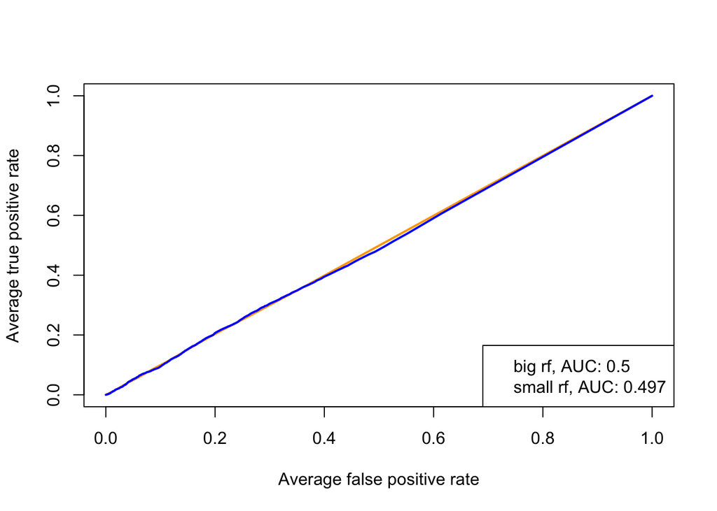

```r
# List observed labels
labels <- split(result_df$observed_label, result_df$fold)

# List of predictions (first random forest)
predictions_rf1 <- split(result_df$prob_positive_rf1, result_df$fold) %>% prediction(labels)

# List of predictions (second random forest)
predictions_rf2 <- split(result_df$prob_positive_rf2, result_df$fold) %>% prediction(labels)

# Average AUC (first random forest)
mean_auc_rf1 <- predictions_rf1 %>%
  performance(measure="auc") %>%
  slot("y.values") %>% unlist() %>%
  mean()

# Average AUC (second random forest)
mean_auc_rf2 <- predictions_rf2 %>%
  performance(measure="auc") %>%
  slot("y.values") %>% unlist() %>%
  mean()

# Plot ROC (first random forest)
predictions_rf1 %>%
  performance(measure="tpr", x.measure="fpr") %>%
  plot(avg="threshold", col="orange", lwd=2)

# Plot ROC (second random forest)
predictions_rf2 %>%
  performance(measure="tpr", x.measure="fpr") %>%
  plot(avg="threshold", col="blue", lwd=2, add=TRUE)

# Make plot pretty
legend("bottomright",
       legend=paste(c("big", "small"), "rf, AUC:", round(c(mean_auc_rf1, mean_auc_rf2), digits=3)),
       col=c("orange", "blue"))
```

## Conclusion

All in all this dataset is very useful for someone looking to get a peek into the industry for possible pitfalls, competitors, and opportunities however the one area is lacks is the individual company financials. I encourage the reader of this report to do their own analysis on this data and see what else they could experiment with. I also encourage looking online for more robust financial information because that could provide and even more in-depth look into the start-up ecosystem.